# Location of Top FL Private High Schools

February 11, 2017

## Assignment

This is an R Markdown presentation as part of the final project of Developing Data Products course at Coursera.com. Course Project: Shiny Application and Reproducible Pitch.

This peer assessed assignment has two parts.

- Create a Shiny application and deploy it on Rstudio's servers.
- Use Slidify or Rstudio Presenter to prepare a reproducible pitch presentation about the application.

## Shiny Application

- Name of the App: **Location of Top FL Private High Schools**
- Purpose of the App: *To help international students to choose a private high school in Florida based on the ranking and location of the school.*
- Input of the App: Use a **Slider** to select the **Ranking** of the school in FL.
- Output of the App: a **Interactive Map** showing the street location of the school. The map can be zoomed in and out. The school **Name**, **Ranking**, **Address**, **Telephone**, and **Home Page** are also displaced on the main panel.
- `ui.R` and `server.R` code: The code of `ui.R` and `server.R` can be found here [link](https://github.com/smei1227/developingDataProductFinalProject).
- App: Try the `Application` here [link](https://smei1227.shinyapps.io/FLprivateHighSchoolRank/).

## Data Source of the Application

1. Original Data Source The original data source comes from the Niche report - *"2017 Best Private High Schools in Florida"*, link [link](https://k12.niche.com/rankings/private-high-schools/best-overall/s/florida/).
2. Compiled data set `location data.csv' can be found here [link](https://github.com/smei1227/developingDataProductFinalProject).

```
  Ranking                        name             address            city
1       1    Ransom Everglades School   3575 MAIN HIGHWAY           Miami
2       2           Pine Crest School 1501 NE 62nd Street Fort Lauderdale
3       3 Berkeley Preparatory School       4811 Kelly Rd           Tampa
  state zip.code latitude longitude     tel.number
1    FL    33133 25.72280 -80.24417 (305) 460-8800
2    FL    33334 26.20505 -80.13452 (561) 852-2800
3    FL    33615 27.99022 -82.56328 (813) 885-1673
                    home.page
1 http://ransomeverglades.org
2        http://pinecrest.edu
3     http://berkeleyprep.org
```

## App Screen Shot

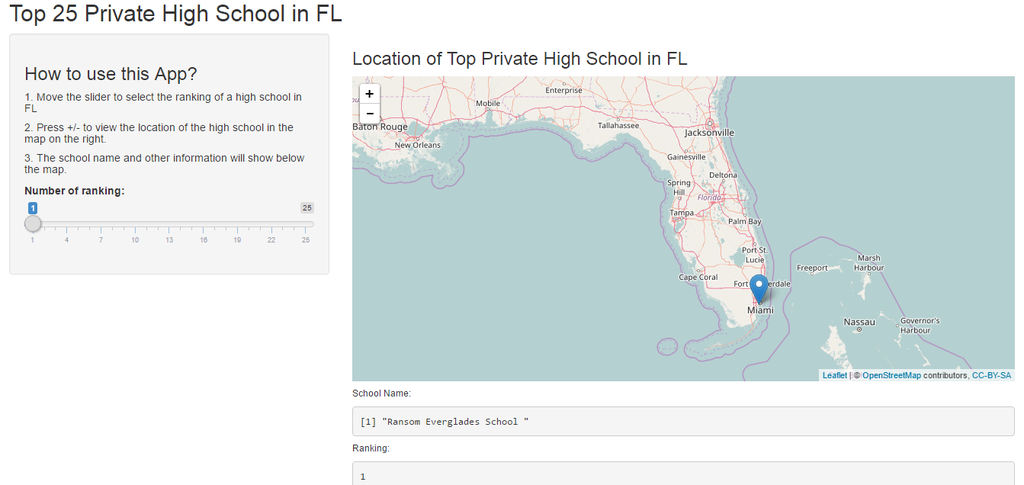

```r
knitr::include_graphics("C:/Users/Mei/Documents/FL private HS/App screenshot.png")
```